# Homework 1: Using OLS Regression to Predict Median House Values in Philadelphia

# Introduction

In this analysis, we will assess the relationship between median house values in Philadelphia and variables such as # Households Living in Poverty, % with Bachelor’s Degree or Higher, % Vacant Houses and % Single House Units.

The predictors in our analysis describe different aspects of housing that could potentially influence house values and prices. The number of households in poverty and with a bachelors degree, to some degree, explain the economic status of the demographic’s housing market. Those living in poverty may not be able to afford houses with higher price tags and those with a bachelors degree may have an income that could afford houses with higher price tags. These population factors indirectly relate to house value, thus why we chose them to predict in our analysis. For unit-specific predictors like vacant houses and single house units, these two signal environmental factors that could influence house value. For vacant houses, we expect that the neighborhood may not be as desirable or may not have high economic activity, making it less desirable to live, which could decrease house values. The percentage of single house units may also highlight the neighborhood’s population. In Philadelphia, it is rare to see single-family detached homes. The common house type are multi-family style houses. So for those living in single-family homes, it indicates the desire to live at longer terms and farther from the city center. These types of homes may single out those with higher incomes to afford a single unit house within a city, which may mean higher house value. All of these predictors indicate something about the housing market population and environment indirectly, making them good examples of variables to predict median house value within Philadelphia.

# Methods

## Data Cleaning

The original Philadelphia Block Group dataset had 1816 observations and was cleaned in order to achieve a dataset with 1720 observations. The following items were removed; Block groups where population < 40, Block groups where there are no housing units, Block groups where the median house value is lower than 10,000, One North Philadelphia block group which had a very high median house value (over 800,000), and a very low median household income (less than $8,000). The purpose of their removal was to remove any outliers, no data, and insufficient sample size from our analysis. All analyses were performed in R.

## Exploratory Analysis

In this section, we will evaluate the summary statistics and distributions of the dependent variable and predictors. In our exploratory data analysis, we will also examine the correlations between the predictors. A correlation is the relationship between two variables. The sample correlation coefficient r, the strength of a linear relationship between two variables (correlation strength) on a -1 to 1 scale, can be calculated with the following equation:
$$r = \frac{\sum (x_i - \bar{x})(y_i -
\bar{y})}{\sqrt{\sum (x_i - \bar{x})^2 \sum (y_i - \bar{y})^2}}$$
The possible range of r values is -1 to 1. A correlation of 0 means there is no linear relationship between the two variables.

```
##                                      Variable         Mean           SD
## MEDHVAL                    Median House Value 66287.733140 60006.075990
## PCTBACHMOR % with Bachelor's Degree or Higher    16.081372    17.769558
## NBELPOV100     # Households Living in Poverty   189.770930   164.318480
## PCTVACANT                     % Vacant Houses    11.288529     9.628472
## PCTSINGLES               % Single House Units     9.226473    13.249250
```

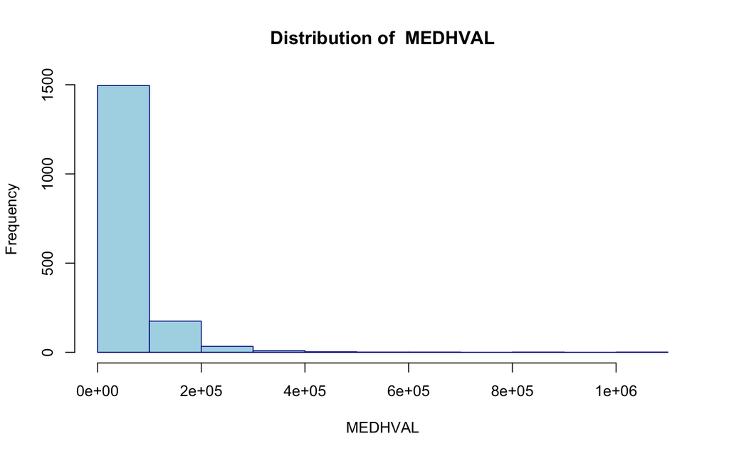

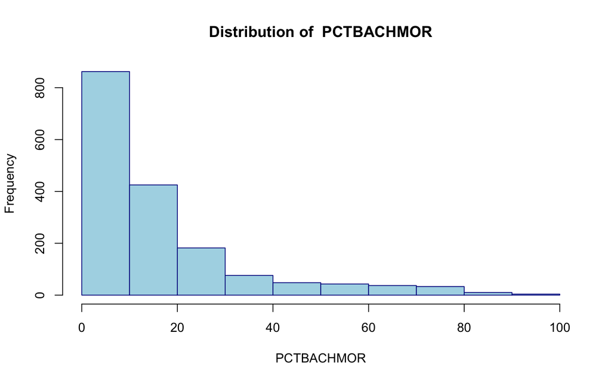

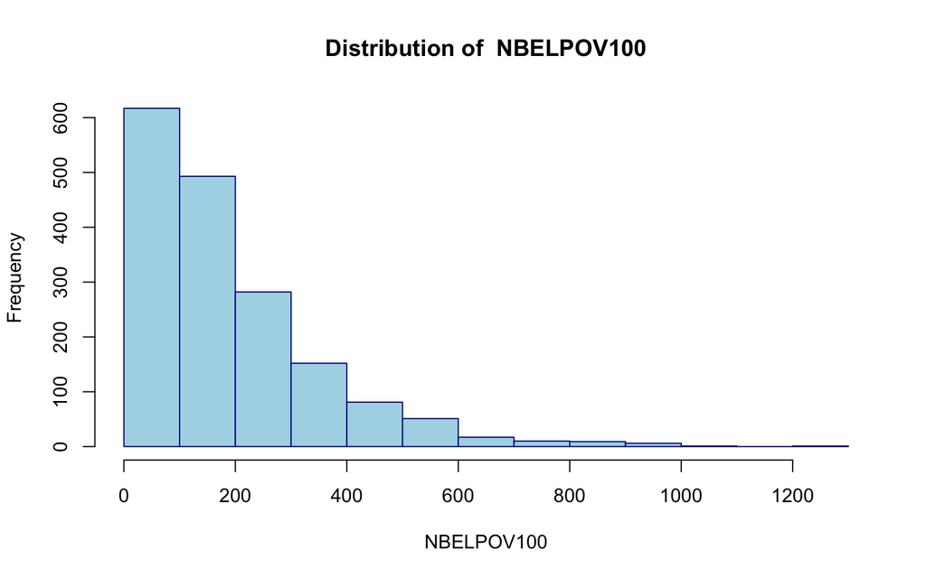

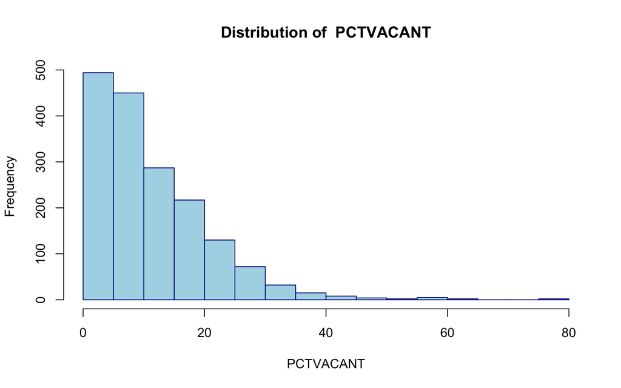

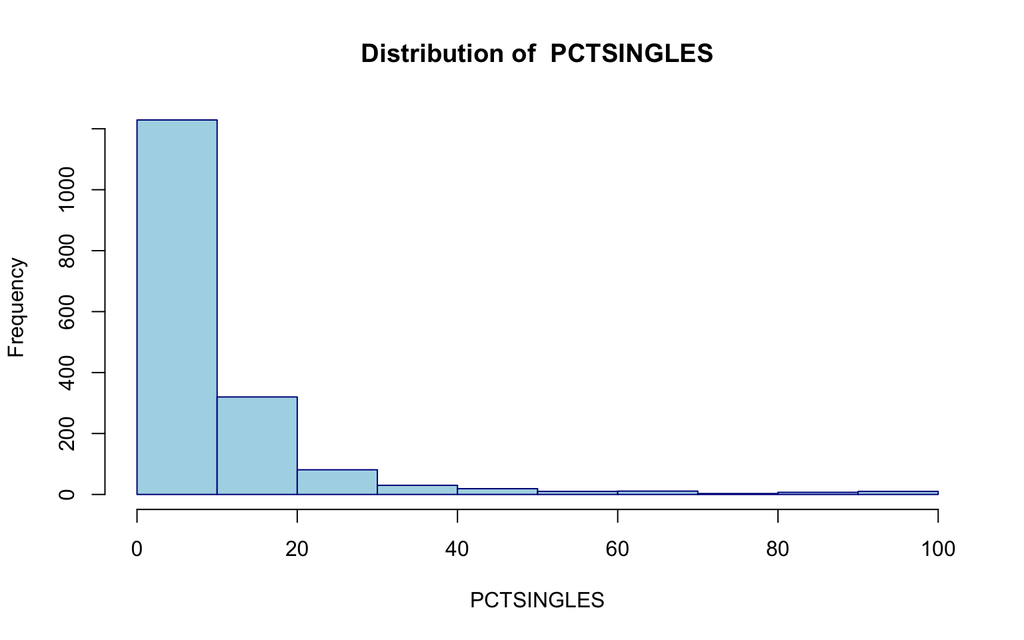

## Regression Analysis Methods

Analysis Multiple linear regression models how a continuous dependent variable changes with several predictors at once. Our model is:

$$LNMEDHVAL = \beta_0 + \beta_1 PCTVACANT
+ \beta_2 PCTSINGLES + \beta_3 PCTBACHMOR + \beta_4 LNNBELPOV100 +
\varepsilon$$

where $\beta_0$ is the intercept, each $\beta_i$ is the expected change in LNMEDHVAL for a one-unit change in that predictor holding the others constant, and $\varepsilon$ is the random error. LNMEDHVAL and LNNBELPOV100 are natural-log transformed. The model assumes linearity, independent observations, normally distributed residuals, constant error variance (homoscedasticity), and no severe multicollinearity among the predictors.

The parameters to estimate are $\beta_0, \dots, \beta_4$ and the error variance $\sigma^2$, the variance of $\varepsilon$. The coefficients are estimated by least squares, which minimizes the sum of squared residuals: $\hat{\boldsymbol{\beta}} = (X^{T}X)^{-1}X^{T}y$.

The coefficient of multiple determination is $R^2 = SSR/SST = 1 - SSE/SST$, where SSE is the error sum of squares, SSR the regression sum of squares, and SST the total sum of squares. The adjusted $R^2 = 1 - \frac{SSE/(n-k-1)}{SST/(n-1)}$ penalizes the number of predictors $k$ ($n$ is the number of observations).

We test the overall model with the F-ratio, $F = \frac{SSR/k}{SSE/(n-k-1)}$, where $H_0: \beta_1 = \dots = \beta_4 = 0$ and $H_a$: at least one $\beta_i \neq 0$. For each predictor, we test $H_0: \beta_i = 0$ against $H_a: \beta_i \neq 0$ using a t-test.

### Additional Analyses

Stepwise regression adds or removes predictors one at a time, keeping changes that lower the Akaike Information Criterion (AIC = $2p - 2\ln(\hat{L})$, where $p$ is the number of parameters and $\hat{L}$ is the maximized likelihood). Its limitations are that it is greedy and may miss the best model, it can overfit, its p-values are overly optimistic, and it ignores theory.

K-fold cross-validation (k = 5) tests how well a model predicts data it was not fit to. The data are split into five folds. Each fold is held out in turn while the model is fit to the other four, and the model then predicts the held-out fold. Models are compared using the root mean square error, $RMSE = \sqrt{\frac{1}{n}\sum (y_i - \hat{y}_i)^2}$, where $\hat{y}_i$ is the cross-validated prediction. A smaller RMSE means better prediction.

# Results

According to the summary statistics table, the average Median House Value in Philadelphia, the dependent variable, across the blocks in our sample is 66287.73 with a standard deviation of 60006.08. For the predictor variables: The average % of households with a Bachelors degree or higher is 16.08% with a standard deviation of 17.77%. The average number of households living in poverty is 189 with a standard deviation of 164. The average % Vacant Houses is 11.29% with a standard deviation of 9.63%. The average % Single House Units is 9.23% with a standard deviation of 13.25%.

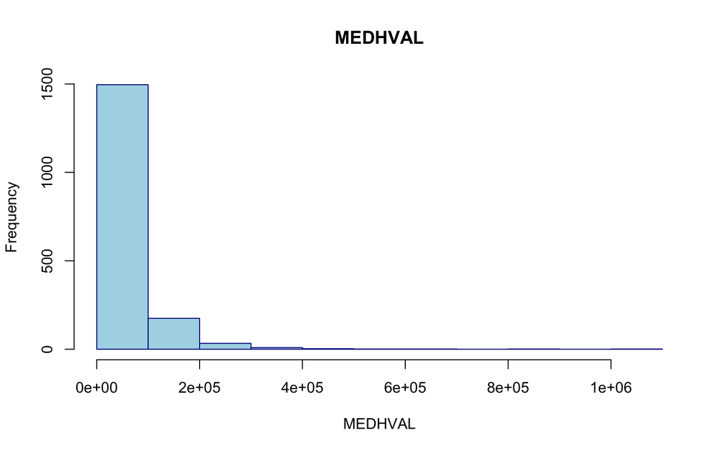

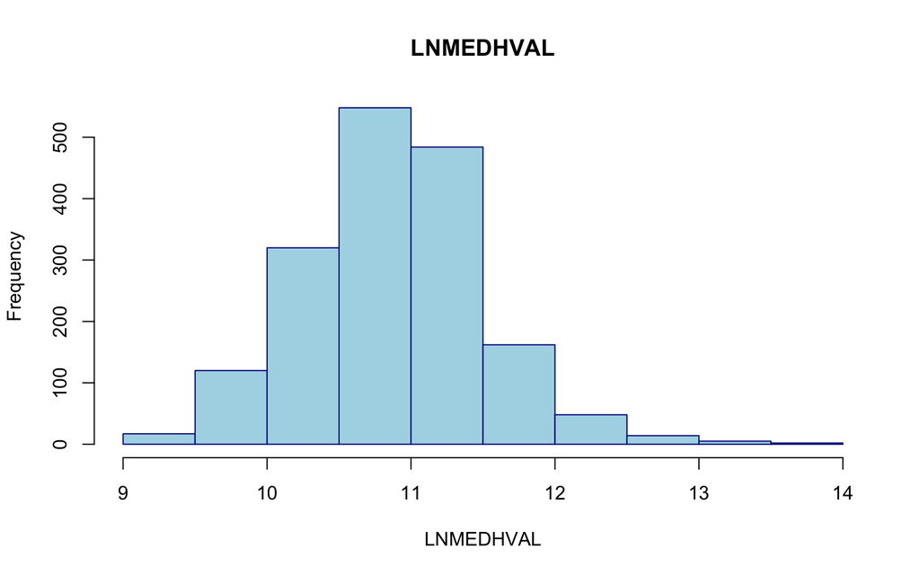

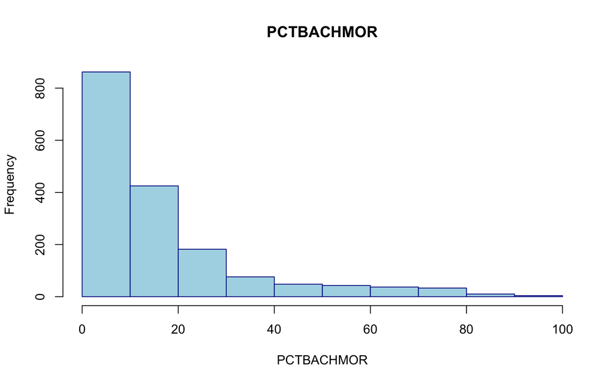

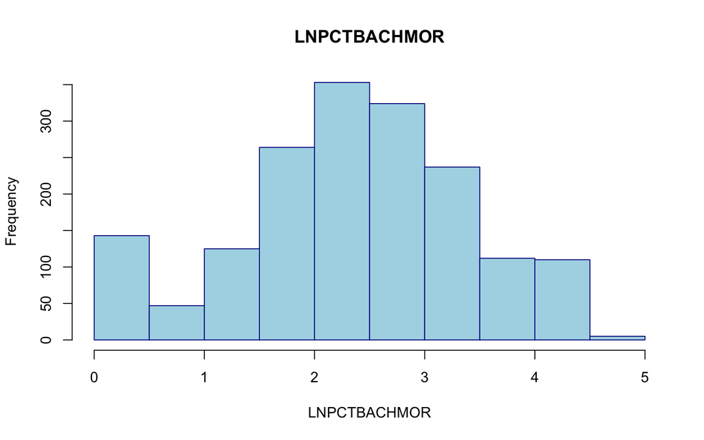

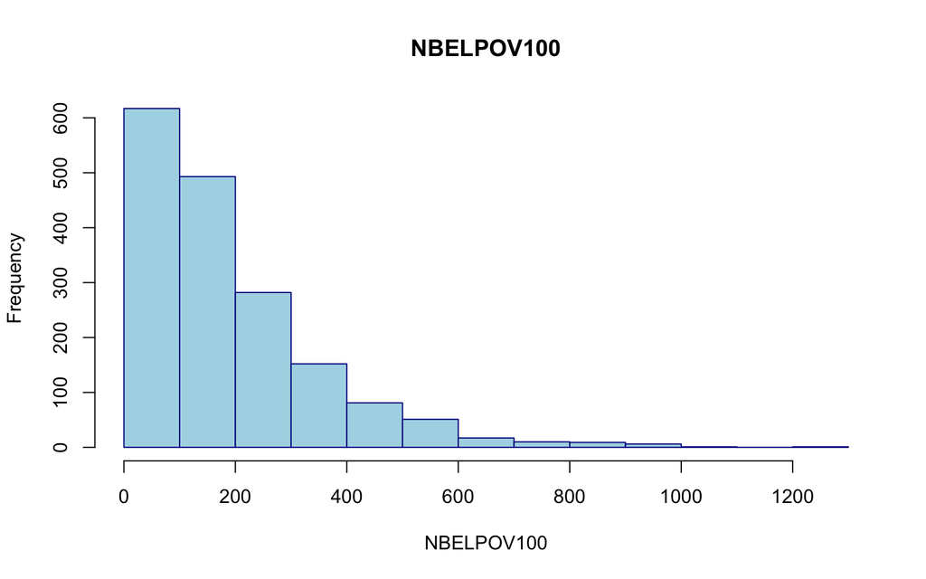

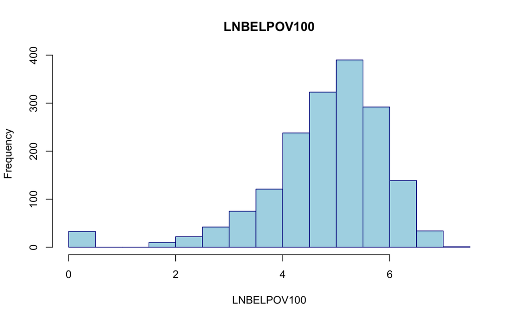

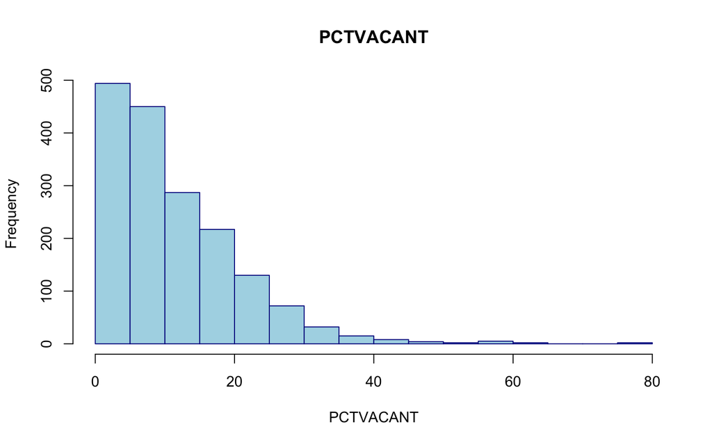

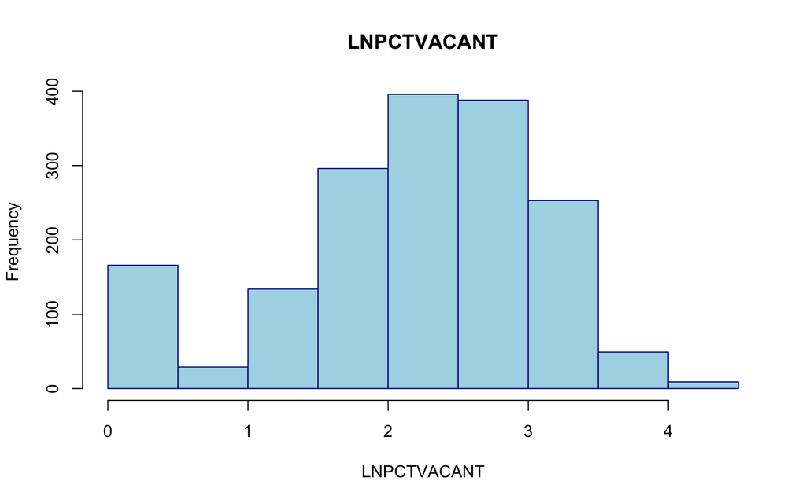

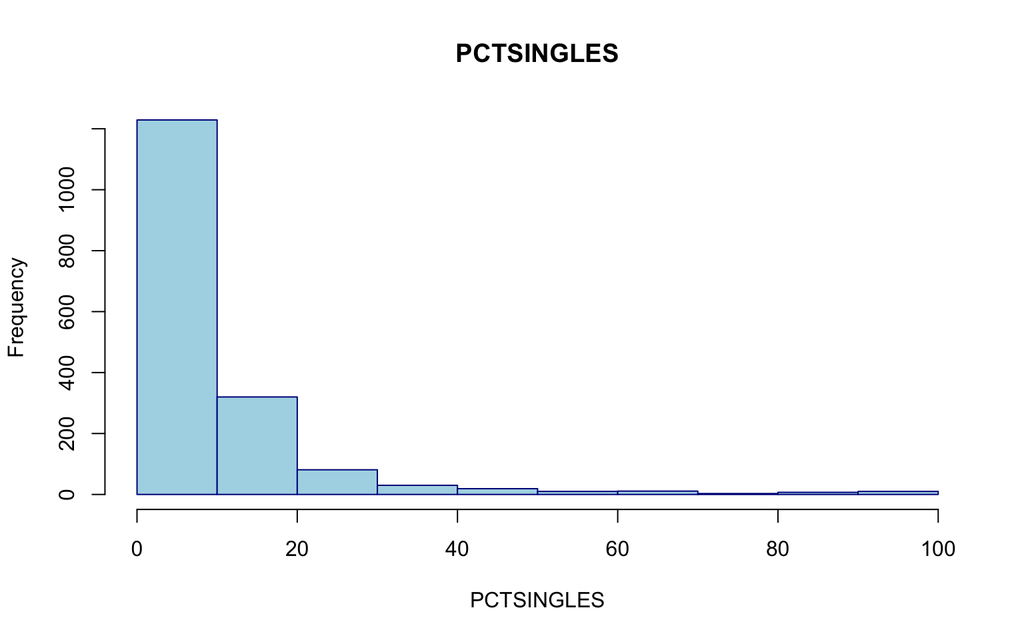

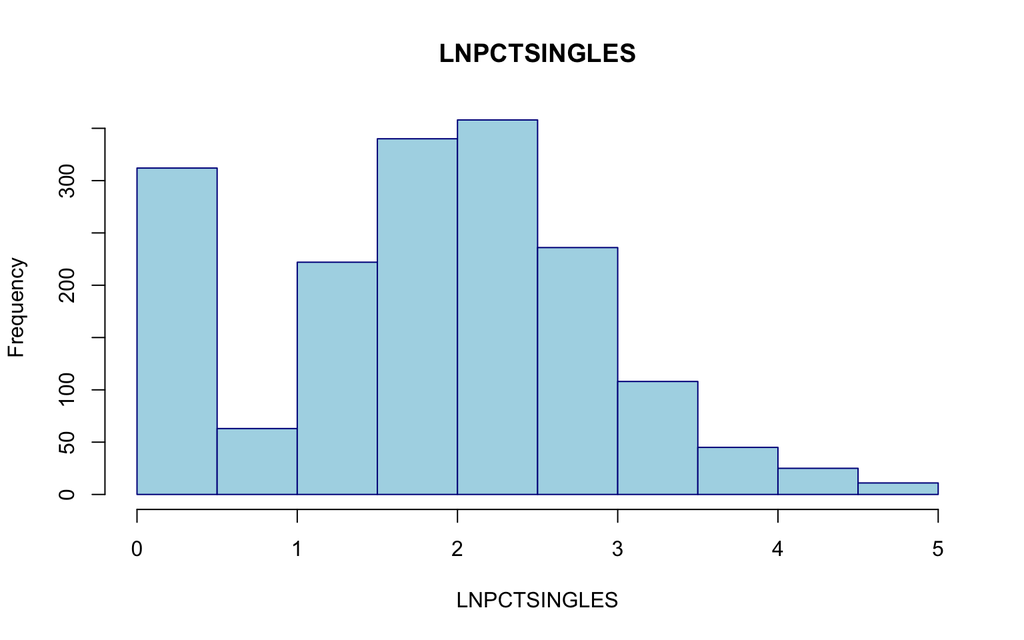

The variables are were not normal before the logarithmic transformation, they were mostly skewed right. Whereas after the logarithmic transformation, they become more normally distributed. In our regression, we use the log-transformed variables for the dependent variable (median house value) and the number of households below poverty predictor. The other regression assumptions will be examined in a separate section below (Regression Assumption Checks).

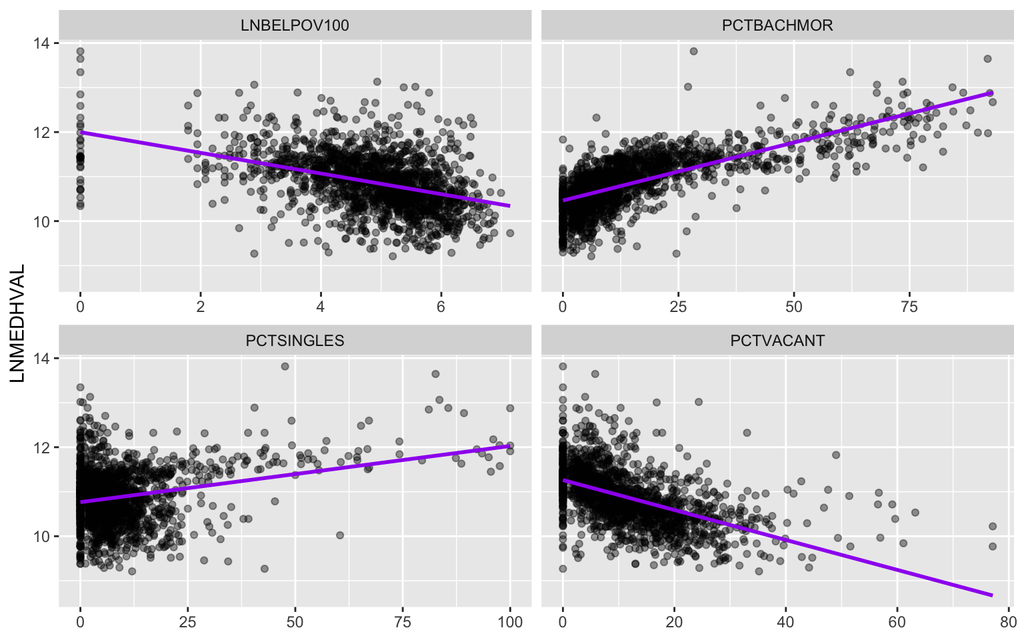

```
##               MEDHVAL PCTBACHMOR NBELPOV100  PCTVACANT PCTSINGLES
## MEDHVAL     1.0000000  0.7031137 -0.2523004 -0.3266071  0.3324373
## PCTBACHMOR  0.7031137  1.0000000 -0.2494608 -0.2983580  0.1975461
## NBELPOV100 -0.2523004 -0.2494608  1.0000000  0.2316880 -0.1636888
## PCTVACANT  -0.3266071 -0.2983580  0.2316880  1.0000000 -0.1513734
## PCTSINGLES  0.3324373  0.1975461 -0.1636888 -0.1513734  1.0000000
```

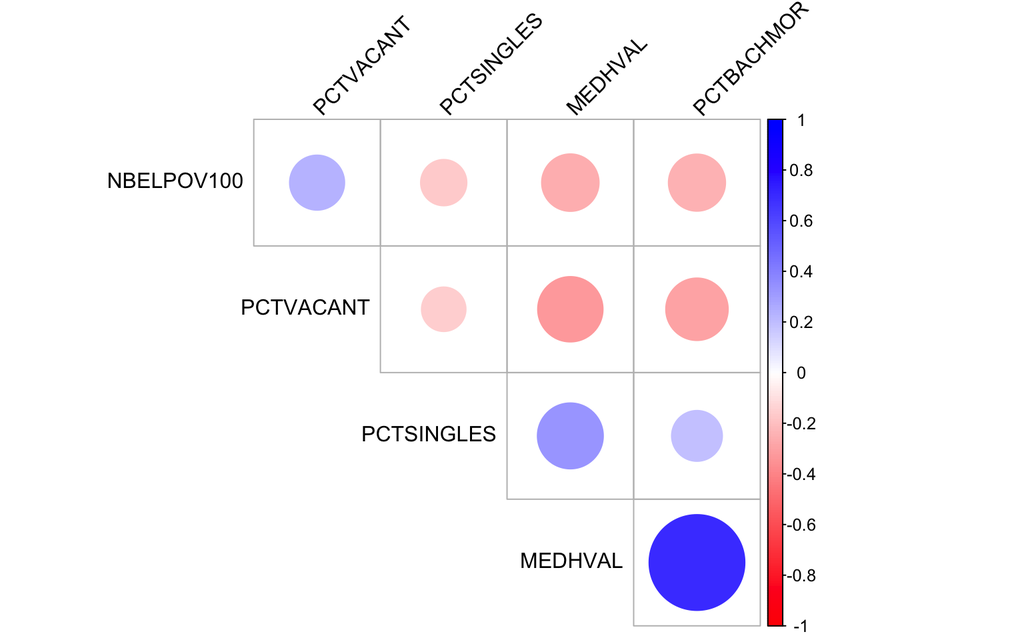

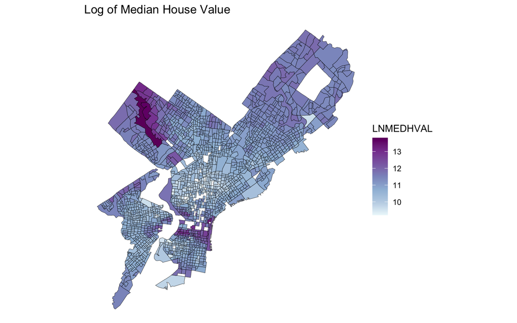

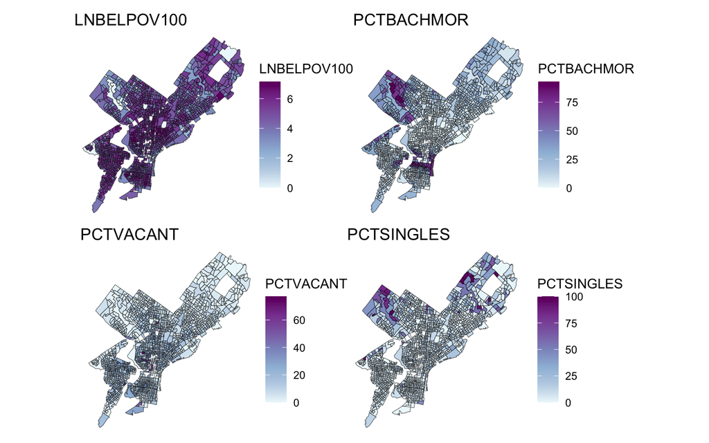

The only maps that look similar are the dependent variable map (log of the median house value) and the percent of households with a bachelors degree or more. The rest of the maps look vastly different. The predictor we expect to be strongly associated with the dependent variable based solely on visualization is the percent of households with a bachelor’s degree and more. The striking similarity of these two maps signals to us that there may be inter-correlation between these variables. We also suspect multicollinearity to be an underlying issue for this similarity.

## Regression Results

```
##
## Call:
## lm(formula = LNMEDHVAL ~ PCTVACANT + PCTSINGLES + PCTBACHMOR +
##     LNBELPOV100, data = regdata)
##
## Residuals:
##      Min       1Q   Median       3Q      Max
## -2.25825 -0.20391  0.03822  0.21744  2.24347
##
## Coefficients:
##               Estimate Std. Error t value Pr(>|t|)
## (Intercept) 11.1137661  0.0465330 238.836  < 2e-16 ***
## PCTVACANT   -0.0191569  0.0009779 -19.590  < 2e-16 ***
## PCTSINGLES   0.0029769  0.0007032   4.234 2.42e-05 ***
## PCTBACHMOR   0.0209098  0.0005432  38.494  < 2e-16 ***
## LNBELPOV100 -0.0789054  0.0084569  -9.330  < 2e-16 ***
## ---
## Signif. codes:  0 '***' 0.001 '**' 0.01 '*' 0.05 '.' 0.1 ' ' 1
##
## Residual standard error: 0.3665 on 1715 degrees of freedom
## Multiple R-squared:  0.6623, Adjusted R-squared:  0.6615
## F-statistic: 840.9 on 4 and 1715 DF,  p-value: < 2.2e-16
```

```
## Analysis of Variance Table
##
## Response: LNMEDHVAL
##               Df  Sum Sq Mean Sq  F value    Pr(>F)
## PCTVACANT      1 180.392 180.392 1343.087 < 2.2e-16 ***
## PCTSINGLES     1  24.543  24.543  182.734 < 2.2e-16 ***
## PCTBACHMOR     1 235.118 235.118 1750.551 < 2.2e-16 ***
## LNBELPOV100    1  11.692  11.692   87.054 < 2.2e-16 ***
## Residuals   1715 230.344   0.134
## ---
## Signif. codes:  0 '***' 0.001 '**' 0.01 '*' 0.05 '.' 0.1 ' ' 1
```

All four predictors are statistically significant (p < 0.0001). Because the dependent variable is logged, coefficients are approximate percentage changes in median house value, holding the other predictors constant:

PCTVACANT ($\hat{\beta}_1$ = -0.0192): each additional percentage point of vacant housing is associated with about a 1.90% decrease in median house value. PCTSINGLES ($\hat{\beta}_2$ = 0.0030): each additional percentage point of single-family homes is associated with about a 0.30% increase. PCTBACHMOR ($\hat{\beta}_3$ = 0.0209): each additional percentage point of residents with a bachelor’s degree or higher is associated with about a 2.11% increase. LNBELPOV100 ($\hat{\beta}_4$ = -0.0789): a 1% increase in the number of households in poverty is associated with about a 0.078% decrease.

For each predictor, the p-value is the probability of an estimate this large if the true coefficient were zero, so we reject $H_0: \beta_i = 0$ for all four. The model explains about 66% of the variance in LNMEDHVAL ($R^2$ = 0.6623, adjusted $R^2$ = 0.6615). The F-ratio is 840.9 on 4 and 1715 degrees of freedom (p < 0.0001), so we reject the null that all coefficients are zero.

### Regression Assumption Checks

We examined the variable distributions earlier. The scatter plots of LNMEDHVAL against each predictor do not look cleanly linear, since PCTVACANT, PCTSINGLES and PCTBACHMOR all have clusters at or near zero and PCTSINGLES is only weakly related to LNMEDHVAL. Standardized residuals are residuals divided by their estimated standard deviation, so values beyond $\pm 2$ are unusual and beyond $\pm 3$ are potential outliers. The histogram of the standardized residuals is shown in the Standardized Regression Residuals section.

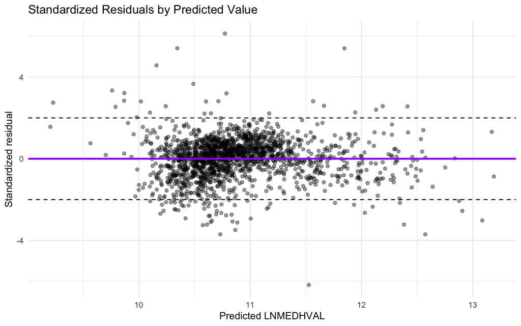

```
## [1] 85
```

```
## [1] 20
```

In the plot of standardized residuals against predicted values, 85 block groups (about 4.9%) fall beyond $\pm 2$ and 20 fall beyond $\pm 3$, so there are some outliers. The spread is mostly even but is somewhat wider at the lowest and highest predicted values, which suggests mild heteroscedasticity. Together with the non-linear scatter plots, linearity and homoscedasticity are not fully satisfied.

The maps of the dependent variable and predictors show similar values clustering in space, which suggests spatial autocorrelation and that block groups are not fully independent. The map of the standardized residuals (in the next section) shows whether the residuals are also spatially clustered. We will test spatial autocorrelation formally in the next assignment.

### Stepwise Regression Results

```
## Start:  AIC=-3448.07
## LNMEDHVAL ~ PCTVACANT + PCTSINGLES + PCTBACHMOR + LNBELPOV100
##
##               Df Sum of Sq    RSS     AIC
## <none>                     230.34 -3448.1
## - PCTSINGLES   1     2.407 232.75 -3432.2
## - LNBELPOV100  1    11.692 242.04 -3364.9
## - PCTVACANT    1    51.546 281.89 -3102.7
## - PCTBACHMOR   1   199.020 429.36 -2379.0
```

```
##   Step Df Deviance Resid. Df Resid. Dev       AIC
## 1      NA       NA      1715   230.3435 -3448.073
```

```
## LNMEDHVAL ~ PCTVACANT + PCTSINGLES + PCTBACHMOR + LNBELPOV100
```

Stepwise regression starting from the full model (AIC = -3448.1) did not drop any predictor, because removing any of them would raise the AIC. All four predictors are therefore kept in the final model.

### K-fold Cross Validation

```
## [1] 1720
```

```
##
## Call:
## lm(formula = LNMEDHVAL ~ PCTVACANT + MEDHHINC, data = cv_data)
##
## Residuals:
##      Min       1Q   Median       3Q      Max
## -1.51313 -0.24807 -0.04362  0.20179  2.82016
##
## Coefficients:
##               Estimate Std. Error t value Pr(>|t|)
## (Intercept)  1.043e+01  3.301e-02  315.94   <2e-16 ***
## PCTVACANT   -1.864e-02  1.223e-03  -15.24   <2e-16 ***
## MEDHHINC     2.099e-05  7.226e-07   29.05   <2e-16 ***
## ---
## Signif. codes:  0 '***' 0.001 '**' 0.01 '*' 0.05 '.' 0.1 ' ' 1
##
## Residual standard error: 0.4426 on 1717 degrees of freedom
## Multiple R-squared:  0.5068, Adjusted R-squared:  0.5063
## F-statistic: 882.3 on 2 and 1717 DF,  p-value: < 2.2e-16
```

| Model | RMSE |
| --- | --- |
| Full model: 4 predictors | 0.3682 |
| Reduced model: PCTVACANT + MEDHHINC | 0.4435 |

The four-predictor model has a cross-validated RMSE of 0.3682, compared with 0.4435 for the model with only PCTVACANT and MEDHHINC. The four-predictor model has the lower RMSE, so it predicts held-out median house values better. The RMSE is in log-dollar units.

### Standardized Regression Residuals

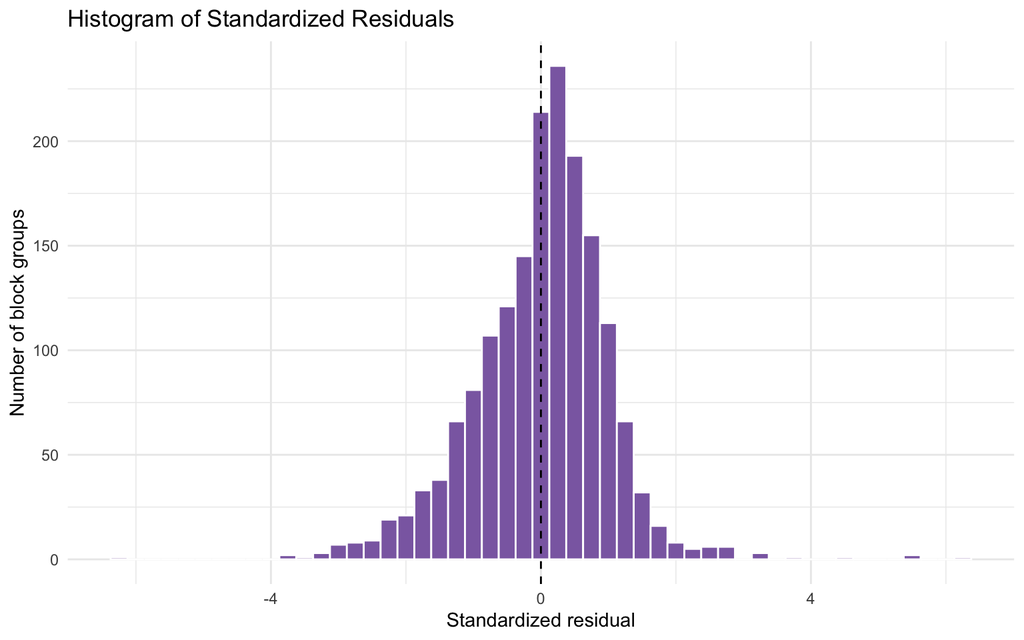

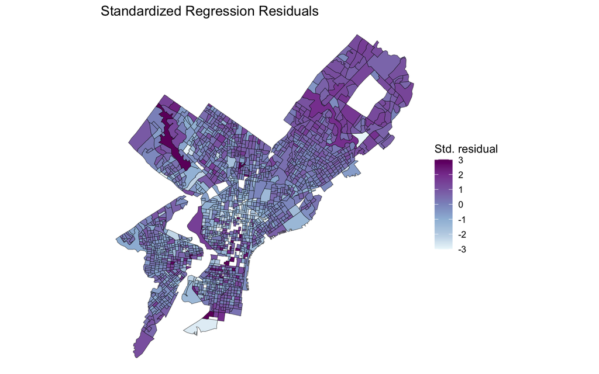

The histogram of standardized residuals is roughly symmetric and centered at zero (mean = 0.0001, median = 0.10), so the normality assumption is reasonably met for most block groups. However, the histogram has a taller, narrower peak than a normal curve and longer tails. The share of block groups beyond ±2 (4.9%) is close to the roughly 5% expected under normality, but the share beyond ±3 (1.2%) is about four times the expected 0.3%, with the most extreme values at −6.18 and 6.13. On the map, values beyond ±3 are shown at the ends of the color scale.

# Discussion

In this report, our team used OLS regression to examine how median house value in 1,720 Philadelphia block groups relates to vacancy, single-family housing, educational attainment and poverty. All four predictors were statistically significant. Vacancy and poverty were associated with lower house values, and educational attainment and single-family housing with higher ones. Of note was how unevenly the predictors contributed. The percentage of residents with a bachelor’s degree was by far the strongest predictor, while the percentage of single-family homes, though significant, added the least. The weaker role of PCTSINGLES may reflect how few detached single-family homes there are in a city made up mostly of rowhouses.

Overall, the model performs reasonably well and explains about two-thirds of the variance in log median house value (R² = 0.6623). The F-test shows that the predictors together are significantly related to it. Stepwise regression kept all four predictors, which suggests each one provided useful information. However, stepwise regression only chooses among the variables it is given, so it cannot tell us what the model may be missing. Cross-validation showed that the four-predictor model predicts new data better than the two-predictor model (RMSE of 0.3682 vs. 0.4435), and its cross-validated RMSE is close to its residual standard error (0.3665). This suggests the model is not overfitting. Still, about a third of the variance is unexplained. Variables of what affects house values that we did not include but would like to examine include: age, size and condition of the housing; distance to downtown area and to transit; school quality; crime rates; access to greenspaces and bluespaces; and the effects of historical redlining.

As discussed in the Regression Assumption Checks, the model violates several OLS assumptions. Relationships between the predictors and log median house value are not fully linear, and the residuals show mild heteroscedasticity. The residuals are close to normal but have more extreme values than a normal distribution would produce, pointing to a small number of block groups the model fits poorly. More critically, the maps of the variables and of the residuals show that neighboring block groups have similar values, so the observations are likely not independent. When residuals are spatially autocorrelated, OLS tends to underestimate the standard errors, which makes the p-values too small and raises the chance of finding a relationship that is not there. If house values in one block group directly affect values in nearby block groups, the coefficient estimates may also be biased.

Another limitation is that NBELPOV100 (Households below Poverty Levels) is a raw count rather than a percentage. Because it is not divided by the total number of households, it partly measures block group size instead of poverty. For example, a block group with 1,500 households and 150 in poverty (10%) and one with 300 households and 150 in poverty (50%) get the same value. As a result, the coefficient mixes the effect of poverty with the effect of population size. Percentage of households in poverty may be a better measure.

Lastly, ridge and LASSO regression would not add much to this analysis. Both methods add a penalty that shrinks coefficients toward zero, accepting a small amount of bias in exchange for more stable estimates. Ridge regression is mainly used when predictors are highly correlated with each other. LASSO can shrink some coefficients all the way to zero, removing those predictors, and is most useful when there are many possible predictors to choose from. However, this model has only four predictors and 1,720 observations, the predictors are not strongly correlated with each other, and stepwise regression kept all four. Shrinking the coefficients would also make them harder to interpret.

Taken together, our results suggest that neighborhood education levels, vacancy and poverty are closely tied to house values across Philadelphia, with educational attainment showing the strongest association. The model is useful for describing these relationships, but its weakness is in that block groups near each other share similar house values and similar prediction errors, which OLS does not account for.